# Lending Mortage Analysis - Modeling

Exploratory Data Analysis

Marjorie Blanco, Joe Thompson, Haodi Tu

The data set contains 1888 records. The overall descriptive statistics:

```
##     Married     Meet credit history guidelines
##  No     : 638   No : 163
##  Unknown:   2   Yes:1725
##  Yes    :1248
##
##
##
##  Other obligations as a percent of total income non-Hispanic Black
##  Min.   : 0.00                                  No :1701
##  1st Qu.:28.00                                  Yes: 187
##  Median :33.00
##  Mean   :32.36
##  3rd Qu.:37.00
##  Max.   :95.00
##  Hispanic    Male      Mortgage loan approved Loan amount/purchase price %
##  No :1784   No : 352   No : 228               Min.   : 2.105
##  Yes: 104   Yes:1536   Yes:1660               1st Qu.:69.262
##                                               Median :80.000
##                                               Mean   :75.442
##                                               3rd Qu.:89.613
##                                               Max.   :99.760
##                  Race
##  Hispanic          : 104
##  non-Hispanic Black: 187
##  non-Hispanic White:1597
##
##
##
```

## Data Discription

The data set includes the following variables:

- APPROVE = 1 if mortgage loan was approved, = 0 otherwise
- GDLIN = 1 if credit history meets guidelines, = 0 otherwise
- LOANPRC = loan amount/purchase price
- OBRAT = other obligations as a percent of total income
- MALE = 1 if male, = 0 otherwise
- MARRIED = 1 if married, = 0 otherwise
- BLACK = 1 if black, = 0 otherwise
- HISPAN = 1 if Hispanic, = 0 otherwise

## Logistic Model

log(p/1-p) = $b_0 + b_1 * GDLIN + b_2 * OBRAT + b_3 * BLACK + b_4 * HISPAN + b_5 * LOANPRC$

```
##
## Call:  glm(formula = APPROVE ~ GDLIN + OBRAT + BLACK + HISPAN + LOANPRC,
##     family = "binomial", data = data)
##
## Coefficients:
## (Intercept)       GDLIN1        OBRAT       BLACK1      HISPAN1
##     1.53274      3.73675     -0.03122     -0.91714     -0.82664
##     LOANPRC
##    -0.01670
##
## Degrees of Freedom: 1887 Total (i.e. Null);  1882 Residual
## Null Deviance:       1391
## Residual Deviance: 902.5     AIC: 914.5
```

```
## Wald test for GDLIN
##  in glm(formula = APPROVE ~ GDLIN + OBRAT + BLACK + HISPAN + LOANPRC,
##     family = "binomial", data = data)
## F =  284.7254  on  1  and  1882  df: p= < 0.000000000000000222
```

```
## Wald test for OBRAT
##  in glm(formula = APPROVE ~ GDLIN + OBRAT + BLACK + HISPAN + LOANPRC,
##     family = "binomial", data = data)
## F =  7.707532  on  1  and  1882  df: p= 0.0055535
```

```
## Wald test for BLACK
##  in glm(formula = APPROVE ~ GDLIN + OBRAT + BLACK + HISPAN + LOANPRC,
##     family = "binomial", data = data)
## F =  13.92077  on  1  and  1882  df: p= 0.00019633
```

```
## Wald test for HISPAN
##  in glm(formula = APPROVE ~ GDLIN + OBRAT + BLACK + HISPAN + LOANPRC,
##     family = "binomial", data = data)
## F =  6.529428  on  1  and  1882  df: p= 0.010688
```

```
## Wald test for LOANPRC
##  in glm(formula = APPROVE ~ GDLIN + OBRAT + BLACK + HISPAN + LOANPRC,
##     family = "binomial", data = data)
## F =  5.229582  on  1  and  1882  df: p= 0.022316
```

For every one unit change in `OBRAT`, the log odds of loan approval (versus non loan approval) decreases by 0.0312188.

For every one unit change in `LOANPRC`, the log odds of loan approval (versus non loan approval) decreases by 0.0167011.

The log odds of loan approval for applicants that meet credit guidelines increases by 3.7367457.

The log odds of loan approval for Black applicants decreases by 0.9171449.

The log odds of loan approval for Hispanic applicants decreases by 0.8266367.

For example, for a black person whose credit history meets guidline (GDLIN = 1), loan amount price is 100 (LOANPRC = 100) and other obligations as a percent of total income is none (OBRAT = 0), the log odds of loan approval is 93.6%

### CIs using profiled log-likelihood

```
##                   2.5 %       97.5 %
## (Intercept)  0.19416207  2.937219042
## GDLIN1       3.31229466  4.182112724
## OBRAT       -0.05333480 -0.009301146
## BLACK1      -1.39135036 -0.426283068
## HISPAN1     -1.43764172 -0.165924717
## LOANPRC     -0.03156216 -0.002916465
```

### CIs using standard errors

```
##                   2.5 %       97.5 %
## (Intercept)  0.16272694  2.902760759
## GDLIN1       3.30270694  4.170784503
## OBRAT       -0.05325850 -0.009179045
## BLACK1      -1.39893109 -0.435358718
## HISPAN1     -1.46068910 -0.192584237
## LOANPRC     -0.03101509 -0.002387147
```

### Odds ratios only

```
## (Intercept)      GDLIN1       OBRAT      BLACK1     HISPAN1     LOANPRC
##   4.6308658  41.9612143   0.9692635   0.3996585   0.4375183   0.9834376
```

### Odds ratios and 95% CI

```
##                     OR      2.5 %     97.5 %
## (Intercept)  4.6308658  1.2142931 18.8633152
## GDLIN1      41.9612143 27.4480373 65.5040992
## OBRAT        0.9692635  0.9480625  0.9907420
## BLACK1       0.3996585  0.2487392  0.6529315
## HISPAN1      0.4375183  0.2374872  0.8471100
## LOANPRC      0.9834376  0.9689307  0.9970878
```

| GDLIN | OBRAT | BLACK | HISPAN | LOANPRC | fit | PredictedProb |
| --- | --- | --- | --- | --- | --- | --- |
| 0 | 32.35767 | 1 | 0 | 75.44245 | -1.6545412 | 0.1604961 |
| 1 | 32.35767 | 1 | 0 | 75.44245 | 2.0822046 | 0.8891615 |
| 0 | 32.35767 | 0 | 1 | 75.44245 | -1.5640329 | 0.1730687 |
| 1 | 32.35767 | 0 | 1 | 75.44245 | 2.1727128 | 0.8977722 |
| 0 | 32.35767 | 0 | 0 | 75.44245 | -0.7373963 | 0.3235738 |
| 1 | 32.35767 | 0 | 0 | 75.44245 | 2.9993495 | 0.9525447 |

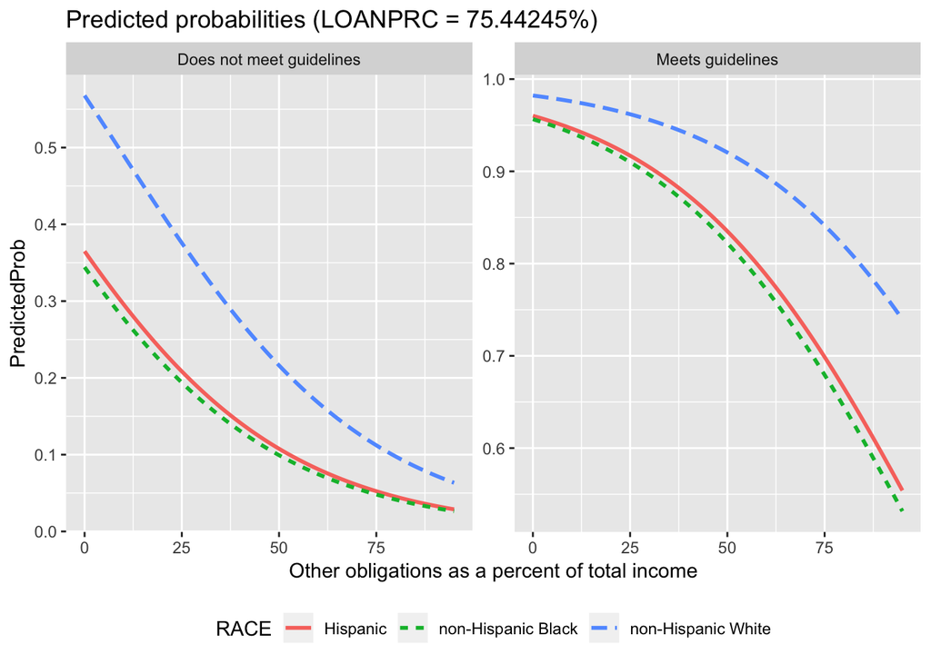

| GDLIN | OBRAT | BLACK | HISPAN | LOANPRC | fit | PredictedProb |
| --- | --- | --- | --- | --- | --- | --- |
| 0 | 32.35767 | 1 | 0 | 2.105000 | -0.4297239 | 0.3941923 |
| 0 | 32.35767 | 1 | 0 | 3.093838 | -0.4462386 | 0.3902555 |
| 0 | 32.35767 | 1 | 0 | 4.082677 | -0.4627533 | 0.3863329 |
| 0 | 32.35767 | 1 | 0 | 5.071515 | -0.4792680 | 0.3824250 |
| 0 | 32.35767 | 1 | 0 | 6.060353 | -0.4957827 | 0.3785323 |
| 0 | 32.35767 | 1 | 0 | 7.049192 | -0.5122974 | 0.3746551 |

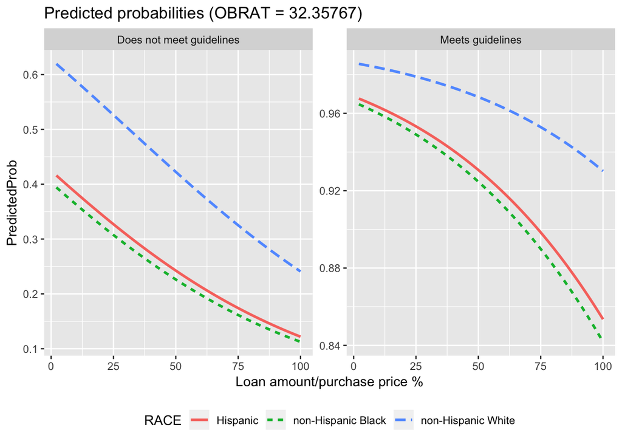

### Probit Model

Probit(approve) = $b_0 + b_1 * GDLIN + b_2 * OBRAT + b_3 * BLACK + b_4 * HISPAN + b_5 * LOANPRC $

```
##
## Call:
## glm(formula = APPROVE ~ GDLIN + OBRAT + BLACK + HISPAN + LOANPRC,
##     family = binomial(link = "probit"), data = data)
##
## Deviance Residuals:
##     Min       1Q   Median       3Q      Max
## -2.8688   0.2496   0.3144   0.3604   2.1669
##
## Coefficients:
##              Estimate Std. Error z value             Pr(>|z|)
## (Intercept)  0.583275   0.341346   1.709             0.087497 .
## GDLIN1       2.161541   0.124153  17.410 < 0.0000000000000002 ***
## OBRAT       -0.014974   0.005721  -2.617             0.008858 **
## BLACK1      -0.473416   0.129376  -3.659             0.000253 ***
## HISPAN1     -0.422091   0.168680  -2.502             0.012338 *
## LOANPRC     -0.007808   0.003404  -2.294             0.021781 *
## ---
## Signif. codes:  0 '***' 0.001 '**' 0.01 '*' 0.05 '.' 0.1 ' ' 1
##
## (Dispersion parameter for binomial family taken to be 1)
##
##     Null deviance: 1391.24  on 1887  degrees of freedom
## Residual deviance:  902.36  on 1882  degrees of freedom
## AIC: 914.36
##
## Number of Fisher Scoring iterations: 6
```

```
##           Overall
## GDLIN1  17.410242
## OBRAT    2.617496
## BLACK1   3.659214
## HISPAN1  2.502317
## LOANPRC  2.294159
```

```
##          llh      llhNull           G2     McFadden         r2ML
## -451.1823406 -695.6182921  488.8719030    0.3513938    0.2281279
##         r2CU
##    0.4375320
```

For every one unit change in `OBRAT`, the probit odds of loan approval (versus non loan approval) decreases by 0.0149739.

For every one unit change in `LOANPRC`, the probit odds of loan approval (versus non loan approval) decreases by 0.0078082.

The probit odds of loan approval for applicants that meet credit guidelines increases by 2.1615407.

The probit odds of loan approval for Black applicants decreases by 0.4734163.

The probit odds of loan approval for Hispanic applicants decreases by 0.4220909.

For example, for a black person whose credit history meets guidline (GDLIN = 1), loan amount price is 100 (LOANPRC = 100) and other obligations as a percent of total income is none (OBRAT = 0), the probit odds of loan approval is 93.2%

| GDLIN | OBRAT | BLACK | HISPAN | LOANPRC | fit |
| --- | --- | --- | --- | --- | --- |
| 0 | 0 | 1 | 0 | 75.44245 | 0.3158938 |
| 0 | 1 | 1 | 0 | 75.44245 | 0.3105874 |
| 0 | 2 | 1 | 0 | 75.44245 | 0.3053201 |
| 0 | 3 | 1 | 0 | 75.44245 | 0.3000927 |
| 0 | 4 | 1 | 0 | 75.44245 | 0.2949063 |
| 0 | 5 | 1 | 0 | 75.44245 | 0.2897615 |

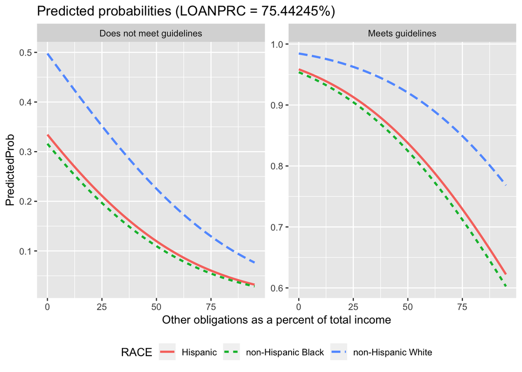

| GDLIN | OBRAT | BLACK | HISPAN | LOANPRC | fit |
| --- | --- | --- | --- | --- | --- |
| 0 | 32.35767 | 1 | 0 | 2.105000 | 0.3478625 |
| 0 | 32.35767 | 1 | 0 | 3.093838 | 0.3450134 |
| 0 | 32.35767 | 1 | 0 | 4.082677 | 0.3421730 |
| 0 | 32.35767 | 1 | 0 | 5.071515 | 0.3393416 |
| 0 | 32.35767 | 1 | 0 | 6.060353 | 0.3365191 |
| 0 | 32.35767 | 1 | 0 | 7.049192 | 0.3337059 |

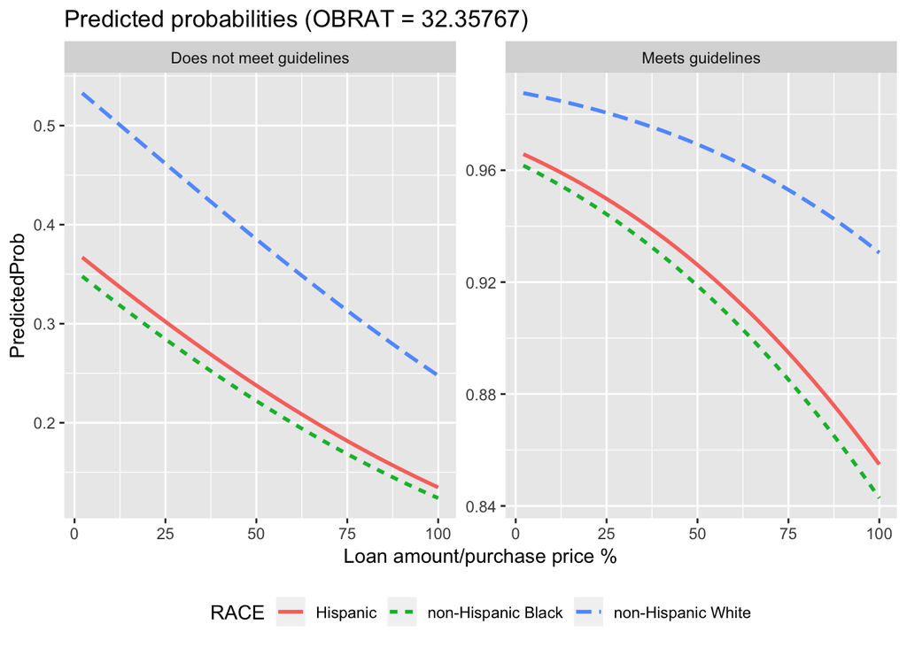